# GLMM

## Outline

- GLM Limitations
- Random Effects Model
- Example

## GLM Limitations

## GLM

- Assumes independent observations

## Repeated measures

- The data shows multiple observations per individual (Case ID). Each individual has data on severity, drug, and outcome measurement in three different time points. (decription on page 456)

|  | case | severity | drug | time | outcome |
| --- | --- | --- | --- | --- | --- |
| 1 | 21 | 0 | 0 | 0 | 1 |
| 2 | 21 | 0 | 0 | 1 | 1 |
| 3 | 21 | 0 | 0 | 2 | 0 |
| 4 | 22 | 0 | 0 | 0 | 1 |
| 5 | 22 | 0 | 0 | 1 | 1 |
| 6 | 22 | 0 | 0 | 2 | 0 |
| 7 | 23 | 0 | 0 | 0 | 1 |
| 8 | 23 | 0 | 0 | 1 | 1 |
| 9 | 23 | 0 | 0 | 2 | 0 |

- GLM would assume each row is independent from others, as if we have 9 independent samples.
- Observations within clusters are usually positively correlated, tending to be more alike than observations from different clusters

## Repeated measures

Reshaping highlights that we only have 3 independent samples, each with multiple observations.

|  | case | severity | drug | 0 | 1 | 2 |
| --- | --- | --- | --- | --- | --- | --- |
| 1 | 21 | 0 | 0 | 1 | 1 | 0 |
| 2 | 22 | 0 | 0 | 1 | 1 | 0 |
| 3 | 23 | 0 | 0 | 1 | 1 | 0 |

## Natural groupings in data

- This shows yes-no responses on use of contraceptives among women of different ages from three out of 60 districts in Bangladesh.

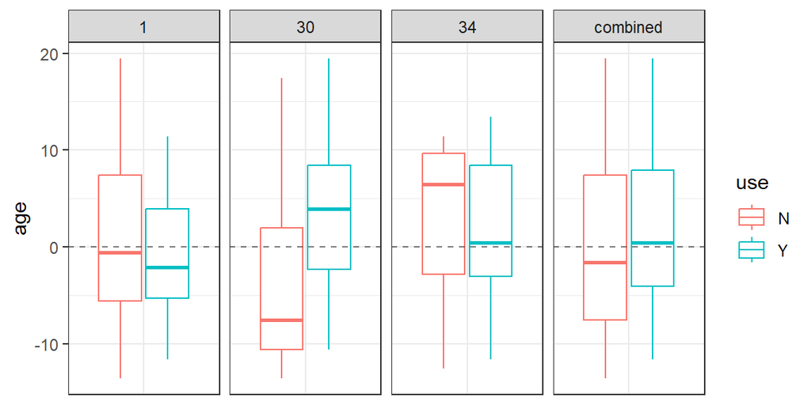

- Ordinary analyses, such as GLM, that ignore the correlation and treat within-cluster observations the same as between-cluster observations produce invalid standard errors, tending to be too small for between-cluster effect estimates and too large for within-cluster effects.

## Natural groupings in data

- Why not use districts as one of the explanatory variables?
  - This dataset actually includes 60 districts. Some of which have very few observations.

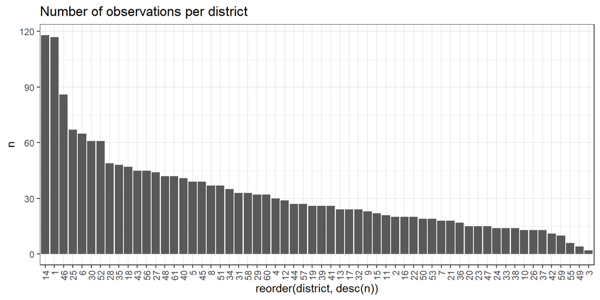

## GLM

- Assumes independent observations
- Observations within clusters are usually positively correlated, tending to be more alike than observations from different clusters.
- Ordinary analyses that ignore the correlation and treat within-cluster observations the same as between-cluster observations produce invalid standard errors, tending to be too small for between-cluster effect estimates and too large for within-cluster effects.
- Solution: add cluster-level terms to the model that take the same value for each observation in a cluster. They are unobserved and when treated as varying randomly among clusters, they are called random effects.

## Random Effects Model

## Definitions

- **Fixed effects** are parameters that describe a factor’s effects in an ordinary GLM. They apply to all categories of interest, such as gender, treatment, or age groupings.
- **Random effects** usually apply to a sample. For a study that makes repeated observations on a sample of subjects, the model treats observations from a given subject as a cluster, and it has a random effect for each of the subject.
- GLMs extend ordinary regression by allowing nonnormal responses and a link function of the mean. The GLMM is a further extension that permits random effects as well as fixed effects in a linear predictor.

## GLMM

- you have \(I\) clusters: \(i = 1, \dots, I\) with \(T_i\) observations in the \(i\)th cluster
- \(y_{it}\): observation \(t\) in cluster \(i\)
- the number of observations may vary by cluster
- \(\mathbf{x}_{it}\): column vector of values of explanatory variables for \(y_{it}\)
- \(\mathbf{u}_i\): vector of random effects for cluster \(i\). This is often univariate. This is assumed to have a multivariate normal distribution \(\mathcal{N}(\mathbf{0}, \boldsymbol{\Sigma})\). The covariance matrix \(\boldsymbol{\Sigma}\) depends on unknown variance components and possible also correlation parameters.
- Conditional on \(\mathbf{u}_i\), a GLMM resembles an ordinary GLM. Conditional on \(\mathbf{u}_i\), standard model fitting treats \(\{y_{it}\}\) as independent over \(t\) and \(i\).
- Let \(\mu_{it} = E(Y_{it} \mid \mathbf{u}_i)\). The linear predictor for a GLMM for link function \(g(\cdot)\) and fixed effect model parameters \(\boldsymbol{\beta}\) has the form

\[ g(\mu_{it}) = \mathbf{x}^T_{it}\boldsymbol{\beta} + \mathbf{z}_{it}^T \mathbf{u}_i \]

## GLMM - Random Intercept

Let \(T = 2\), and \(\boldsymbol{\beta} = \begin{bmatrix} \alpha \\ \beta\end{bmatrix}\).

For a single observation \((i, t)\), the formula is

\[ g(\mu_{it}) = \mathbf{x}^T_{it}\boldsymbol{\beta} + \mathbf{z}_{it}^T \mathbf{u}_i \]

If \(\mathbf{u}_i\) is univariate, we can either have a random slope or a random intercept. Suppose we have a random intercept. Note that \(u_i \sim\mathcal{N}(0, \sigma^2)\)

\[ \begin{aligned} \begin{bmatrix} g(\mu_{11}) \\ g(\mu_{12}) \\ g(\mu_{21}) \\ g(\mu_{22}) \\ \vdots \\ g(\mu_{I1}) \\ g(\mu_{I2}) \\ \end{bmatrix} &= \begin{bmatrix} \mathbf{x}_{11}^\top \\ \mathbf{x}_{12}^\top \\ \mathbf{x}_{21}^\top \\ \mathbf{x}_{22}^\top \\ \vdots \\ \mathbf{x}_{I1}^\top \\ \mathbf{x}_{I2}^\top \\ \end{bmatrix} \begin{bmatrix} \alpha \\ \beta\end{bmatrix} + \begin{bmatrix} \mathbf{z}_{11}^\top \\ \mathbf{z}_{12}^\top \\ \mathbf{z}_{21}^\top \\ \mathbf{z}_{22}^\top \\ \vdots \\ \mathbf{z}_{I1}^\top \\ \mathbf{z}_{I2}^\top \\ \end{bmatrix} \begin{bmatrix} u_1 \\ u_2 \\ \vdots \\ u_I \end{bmatrix} \\ & = \begin{bmatrix} 1 & x_{11} \\ 1 & x_{12} \\ 1 & x_{21} \\ 1 & x_{22} \\ \vdots \\ 1 & x_{I1} \\ 1 & x_{I2} \\ \end{bmatrix} \begin{bmatrix} \alpha \\ \beta\end{bmatrix} + \begin{bmatrix} 1 & 0 & \cdots & 0 \\ 1 & 0 & \cdots & 0 \\ 0 & 1 & \cdots & 0 \\ 0 & 1 & \cdots & 0 \\ \vdots & \vdots & \ddots & \vdots \\ 0 & 0 & \cdots & 1 \\ 0 & 0 & \cdots & 1 \\ \end{bmatrix} \begin{bmatrix} u_1 \\ u_2 \\ \vdots \\ u_I \end{bmatrix} \\ g[E(\mathbf{Y} \mid \mathbf{u})] = g(\boldsymbol{\mu}) &= \mathbf{X}_{(2I)\times 2} \boldsymbol\beta_{2 \times 1} + \mathbf{Z}_{(2I)\times I} \mathbf{u}_{I \times 1}, \qquad \text{matrix notation} \\ \begin{bmatrix} g(\mu_{11}) \\ g(\mu_{12}) \\ g(\mu_{21}) \\ g(\mu_{22}) \\ \vdots \\ g(\mu_{I1}) \\ g(\mu_{I2}) \\ \end{bmatrix} &= \begin{bmatrix} (\alpha + u_1) + x_{11}\beta \\ (\alpha + u_1) + x_{12}\beta \\ (\alpha + u_2) + x_{21}\beta \\ (\alpha + u_2) + x_{22}\beta \\ \vdots \\ (\alpha + u_I) + x_{I1}\beta \\ (\alpha + u_I) + x_{I2}\beta \\ \end{bmatrix} \end{aligned} \]

- Link(Average outcome) = General trend (Fixed) + Cluster deviation (Random)
- \(\alpha\) and \(\beta\) are the fixed effects while \(u_1\) and \(u_2\) are the random effects realization.
- If \(Y_{it} \mid u_i \sim \text{Bernoulli}(\mu_{it})\), \(g = \text{logit}\), and \(x_{it}\) indicates whether treatment is administered or not, we have a logistic GLMM with random intercept for binary matched pairs.
  - an extension allows \(T > 2\) observations in each cluster. The random intercept model has form below and early applications were in psychometrics (item response models).

  \[ \text{logit}[P(Y_{it}=1 \mid u_i)] = \alpha + \beta_t + u_i \]
  - The item-response model with random intercept is a special case of an important class of random effects model for binary data called logistic-normal models for binary data with the form

  \[ \text{logit}[P(Y_{it}=1 \mid u_i)] = \mathbf{x}^T_{it} \boldsymbol{\beta}+ u_i \]

## Heterogeneity in Logistic-Normal models

Take 2 observations from different clusters. Let them be \((x_{it}, y_{it})\) and \((x_{hs}, y_{hs})\). We look at their difference in log-odds.

\[ \text{logit}[P(Y_{it}=1 \mid u_i)] = \mathbf{x}^T_{it} \boldsymbol{\beta}+ u_i \]

\[ \text{logit}[P(Y_{hs}=1 \mid u_h)] = \mathbf{x}^T_{hs} \boldsymbol{\beta}+ u_h \]

\[ \begin{aligned} \text{logit}[P(Y_{it}=1 \mid u_i)] - \text{logit}[P(Y_{hs}=1 \mid u_h)] &= \mathbf{x}^T_{it} \boldsymbol{\beta} + u_i - \mathbf{x}^T_{hs} \boldsymbol{\beta} - u_h \\ &= (\mathbf{x}^T_{it} - \mathbf{x}^T_{hs}) \boldsymbol{\beta} + (u_i - u_h) \\ &= (\mathbf{x}_{it} - \mathbf{x}_{hs})^T \boldsymbol{\beta} + (u_i - u_h) \end{aligned}s \]

- Fixed part: \((\mathbf{x}_{it} - \mathbf{x}_{hs})^T \boldsymbol{\beta}\)
- Random part: \((u_i - u_h) \sim \mathcal{N}(0, 2 \sigma^2)\)
- \(u_i - u_h\) captures additional variation in log-odds due to cluster-level heterogeneity.

If \(\sigma = 0\), there is no variation across clusters - the logistic-normal model simplifies to the ordinary logistic regression model, treating all observations as independent.

\[ \begin{aligned} \text{logit}[P(Y_{it}=1 \mid u_i)] - \text{logit}[P(Y_{hs}=1 \mid u_h)] &= (\mathbf{x}_{it} - \mathbf{x}_{hs})^T \boldsymbol{\beta} + (u_i - u_h) \\ &= (\mathbf{x}_{it} - \mathbf{x}_{hs})^T \boldsymbol{\beta} \end{aligned} \]

If \(\sigma > 0\), \((\mathbf{x}_{it} - \mathbf{x}_{hs})^T \boldsymbol{\beta} + (u_i - u_h)\) only reduces to \((\mathbf{x}_{it} - \mathbf{x}_{hs})^T \boldsymbol{\beta}\) if \(u_i = u_h\) — when observations come from the same cluster.

## Form: GLM vs GLMM

Suppose we use the logit link:

GLM

\[ \text{logit}[P(Y_{it}=1)] = \mathbf{x}^T_{it} \boldsymbol{\beta} \]

GLMM; \(u_i \sim \mathcal{N}(0,\sigma^2)\)

\[ \text{logit}[P(Y_{it}=1 \mid u_i)] = \mathbf{x}^T_{it} \boldsymbol{\beta}+ u_i \]

## Random effects: unmeasured predictors

The random effects sometimes represent heterogeneity caused by omitting certain explanatory variables. Suppose we only have \(p-1\) predictors,

\[ g[E(\mathbf{y})] = g(\boldsymbol{\mu}) = \mathbf{X}_{n \times (p-1)} \boldsymbol{\beta}_{(p-1)\times 1} \]

But the model could have been better explained in the presence of the \(p\)th variable which is unmeasured.

The random effects model relate to methods of dealing with unmeasured predictors. The random effects part of the linear predictor reflects terms that would be in the fixed effects part if those explanatory variables had been included.

\[ g[E(\mathbf{y})] = \mathbf{X}_{n \times (p-1)} \boldsymbol{\beta}_{(p-1)\times 1} + \mathbf{Z}_{n \times q}\mathbf{u}_{q \times 1} \]

## Random effects: random measurement error in the explanatory variables

Random effects also sometimes represent random measurement error in the explanatory variables.

If we replace a particular \(x_{it}\) by \(x^*_{it} + \epsilon_i\), with \(x^*_{it}\) the true values and \(\epsilon_i\) the measurement error, then \(\epsilon_i\beta\) can be absorbed in the random effects term.

\[ \begin{aligned} g(\mu_{it}) &= \mathbf{x}^T_{it}\boldsymbol{\beta} + \mathbf{z}_{it}^T \mathbf{u}_i \\ &= (\mathbf{x}^{T*}_{it} + \epsilon_i)\boldsymbol{\beta} + \mathbf{z}_{it}^T \mathbf{u}_i \\ &= \mathbf{x}^{T*}_{it}\boldsymbol{\beta} + \epsilon_i\boldsymbol{\beta} + \mathbf{z}_{it}^T \mathbf{u}_i \end{aligned} \]

## Random effects: explaining overdispersion

Overdispersion occurs when the model underestimates the variance in the outcome; it has the ff implications

- standard errors that are too small
- p-values biased towards significance
- CI too narrow

Potential sources of overdispersion:

- observations are not independent
- external factors influencing the outcome, not included in the model

Random effects provide a mechanism for explaining overdispersion in basic models not having those effects.

## Example

## Dataset

|  | woman | district | use | livch | age | urban |
| --- | --- | --- | --- | --- | --- | --- |
| 1 | 1 | 1 | N | 3+ | 18.44 | Y |
| 2 | 2 | 1 | N | 0 | -5.5599 | Y |
| 3 | 3 | 1 | N | 2 | 1.44 | Y |
| 4 | 4 | 1 | N | 3+ | 8.44 | Y |
| 5 | 5 | 1 | N | 0 | -13.559 | Y |
| 6 | 6 | 1 | N | 0 | -11.56 | Y |
| 7 | 7 | 1 | N | 3+ | 18.44 | Y |
| 8 | 8 | 1 | N | 3+ | -3.5599 | Y |
| 9 | 9 | 1 | N | 1 | -5.5599 | Y |
| 10 | 10 | 1 | N | 3+ | 1.44 | Y |

[output cut: 1924 more lines]

## Fit a GLM

We ignore the district variable.

```r
model_glm  <- glm(use ~ age + urban + livch,
                  family = binomial,
                  data = Contraception)
```

```
Call:
glm(formula = use ~ age + urban + livch, family = binomial, data = Contraception)

Coefficients:
            Estimate Std. Error z value Pr(>|z|)
(Intercept) -1.56804    0.12623  -12.42  < 2e-16 ***
age         -0.02400    0.00754   -3.18   0.0015 **
urbanY       0.79718    0.10519    7.58  3.5e-14 ***
livch1       1.05919    0.15195    6.97  3.2e-12 ***
livch2       1.28781    0.16724    7.70  1.4e-14 ***
livch3+      1.21638    0.17059    7.13  1.0e-12 ***
---
Signif. codes:  0 '***' 0.001 '**' 0.01 '*' 0.05 '.' 0.1 ' ' 1

(Dispersion parameter for binomial family taken to be 1)

    Null deviance: 2590.9  on 1933  degrees of freedom
Residual deviance: 2456.7  on 1928  degrees of freedom
AIC: 2469

Number of Fisher Scoring iterations: 4
```

## Fit a GLMM

We use random intercept model.

```r
model_glmm0 <- glmer(use ~ age + urban + livch + (1 | district),
                    family = binomial,
                    data = Contraception)
```

```
Generalized linear mixed model fit by maximum likelihood (Laplace
  Approximation) [glmerMod]
 Family: binomial  ( logit )
Formula: use ~ age + urban + livch + (1 | district)
   Data: Contraception

      AIC       BIC    logLik -2*log(L)  df.resid
   2427.6    2466.6   -1206.8    2413.6      1927

Scaled residuals:
   Min     1Q Median     3Q    Max
-1.823 -0.766 -0.508  0.998  2.720

Random effects:
 Groups   Name        Variance Std.Dev.
 district (Intercept) 0.212    0.461
Number of obs: 1934, groups:  district, 60

Fixed effects:
            Estimate Std. Error z value Pr(>|z|)
(Intercept) -1.68965    0.14733  -11.47  < 2e-16 ***
age         -0.02659    0.00788   -3.38  0.00074 ***
urbanY       0.73298    0.11939    6.14  8.3e-10 ***
livch1       1.10913    0.15785    7.03  2.1e-12 ***
livch2       1.37634    0.17464    7.88  3.2e-15 ***
livch3+      1.34518    0.17941    7.50  6.5e-14 ***
---
Signif. codes:  0 '***' 0.001 '**' 0.01 '*' 0.05 '.' 0.1 ' ' 1

Correlation of Fixed Effects:
        (Intr) age    urbanY livch1 livch2
age      0.449
urbanY  -0.289 -0.044
livch1  -0.590 -0.213  0.055
livch2  -0.633 -0.380  0.089  0.489
livch3+ -0.752 -0.675  0.092  0.540  0.620
```

```r
ranef(model_glmm0)
```

```
$district
   (Intercept)
1   -0.7220005
2   -0.0357588
3    0.2044601
4    0.1868071
5    0.0563461
6   -0.2179315
7   -0.1353718
8    0.1129183
9   -0.2217344
10  -0.3697112
11  -0.7015678
12  -0.0862214
13   0.1222621
```

[output cut: 49 more lines]

## Visualize the characteristic curve

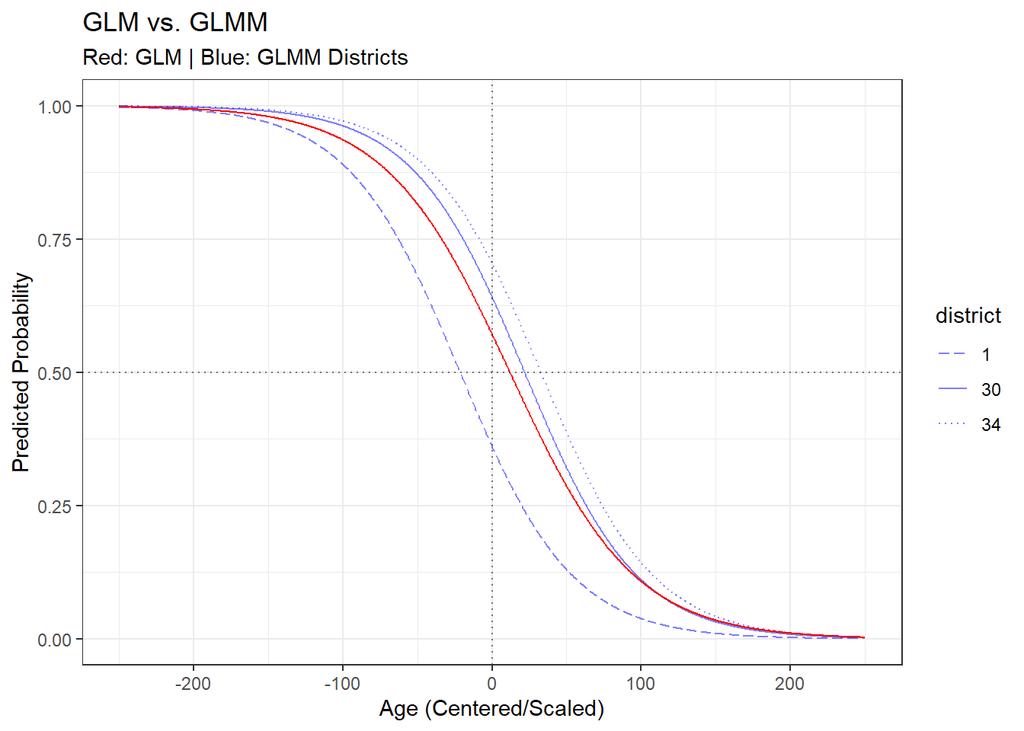

## What happens if

… we fit a GLMM to a dataset but the clusters do not vary?

It gets reduced to a GLM.

### `age` per district

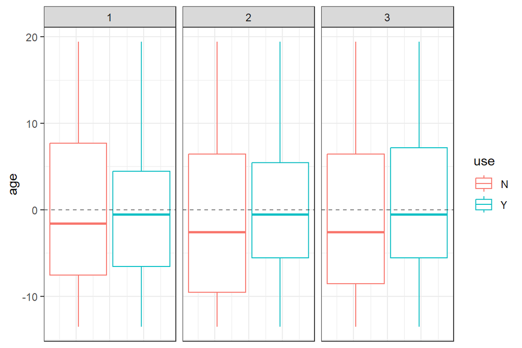

### `livch` per district

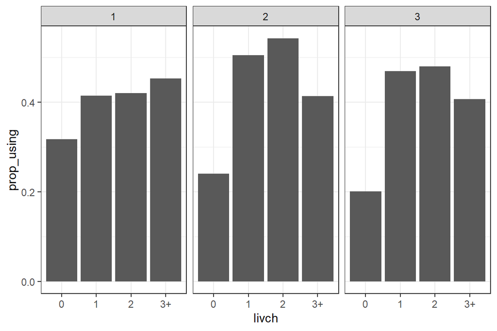

### `urban` per district

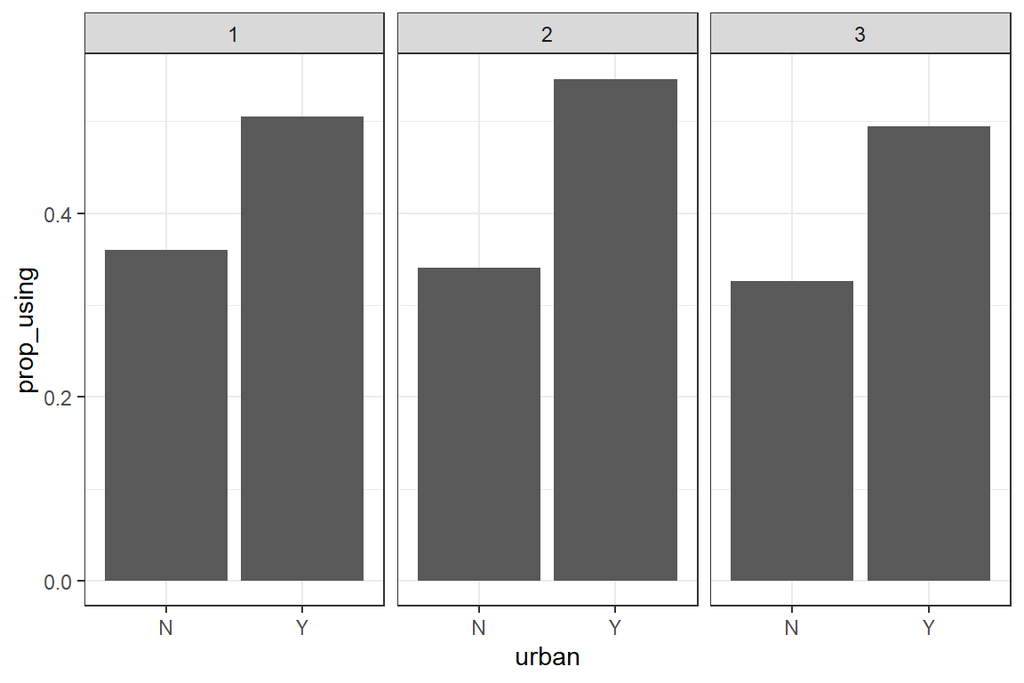

### Fit a GLMM

```r
model_glmm1 <- glmer(use ~ age + urban + livch + (1 | fake_district),
                    family = binomial,
                    data = Contraception)
```

```
Generalized linear mixed model fit by maximum likelihood (Laplace
  Approximation) [glmerMod]
 Family: binomial  ( logit )
Formula: use ~ age + urban + livch + (1 | fake_district)
   Data: Contraception

      AIC       BIC    logLik -2*log(L)  df.resid
   2470.7    2509.7   -1228.4    2456.7      1927

Scaled residuals:
   Min     1Q Median     3Q    Max
-1.470 -0.805 -0.524  1.123  2.424

Random effects:
 Groups        Name        Variance Std.Dev.
 fake_district (Intercept) 0        0
Number of obs: 1934, groups:  fake_district, 3

Fixed effects:
            Estimate Std. Error z value Pr(>|z|)
(Intercept) -1.56804    0.12623  -12.42  < 2e-16 ***
age         -0.02400    0.00754   -3.18   0.0015 **
urbanY       0.79718    0.10519    7.58  3.5e-14 ***
livch1       1.05919    0.15195    6.97  3.2e-12 ***
livch2       1.28780    0.16724    7.70  1.4e-14 ***
livch3+      1.21638    0.17059    7.13  1.0e-12 ***
---
Signif. codes:  0 '***' 0.001 '**' 0.01 '*' 0.05 '.' 0.1 ' ' 1

Correlation of Fixed Effects:
        (Intr) age    urbanY livch1 livch2
age      0.491
urbanY  -0.357 -0.052
livch1  -0.655 -0.200  0.064
livch2  -0.699 -0.368  0.106  0.485
livch3+ -0.832 -0.665  0.112  0.536  0.614
optimizer (Nelder_Mead) convergence code: 0 (OK)
boundary (singular) fit: see help('isSingular')
```

```r
ranef(model_glmm1)
```

```
$fake_district
  (Intercept)
1           0
2           0
3           0

with conditional variances for "fake_district"
```

### Visualize the characteristic curve

Note that the GLM characteristic curve and the three curves corresponding to the 3 fake districts overlap.

When there is no between-cluster variability (\(\sigma^2 =0\)), the GLMM reduces to a GLM.

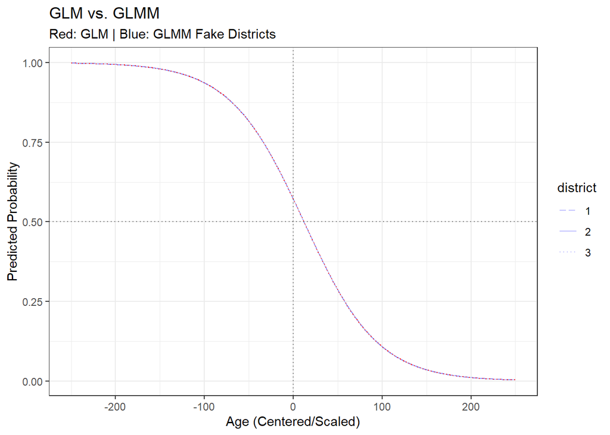

## Appendix

## GLMM - Random Slope

Let \(I = 2\), \(T = 2\), and \(\boldsymbol{\beta} = \begin{bmatrix} \alpha \\ \beta\end{bmatrix}\).

For a single observation \((i, t)\), the formula is

\[ g(\mu_{it}) = \mathbf{x}^T_{it}\boldsymbol{\beta} + \mathbf{z}_{it}^T u_i \]

If \(u_i\) is a **random slope** for the covariate \(x_{it}\), then:

\[ \begin{aligned} \begin{bmatrix} g(\mu_{11}) \\ g(\mu_{12}) \\ g(\mu_{21}) \\ g(\mu_{22}) \\ \end{bmatrix} &= \begin{bmatrix} 1 & x_{11} \\ 1 & x_{12} \\ 1 & x_{21} \\ 1 & x_{22} \\ \end{bmatrix} \begin{bmatrix} \alpha \\ \beta\end{bmatrix} + \begin{bmatrix} x_{11} & 0 \\ x_{12} & 0 \\ 0 & x_{21} \\ 0 & x_{22} \\ \end{bmatrix} \begin{bmatrix} u_1 \\ u_2\end{bmatrix} \\ \\ \begin{bmatrix} g(\mu_{11}) \\ g(\mu_{12}) \\ g(\mu_{21}) \\ g(\mu_{22}) \\ \end{bmatrix} &= \begin{bmatrix} \alpha + x_{11}(\beta + u_1) \\ \alpha + x_{12}(\beta + u_1) \\ \alpha + x_{21}(\beta + u_2) \\ \alpha + x_{22}(\beta + u_2) \\ \end{bmatrix} \end{aligned} \]

- The term \((\beta + u_i)\) represents the cluster-specific slope.
- \(\alpha\) and \(\beta\) are the fixed effects while \(u_1\) and \(u_2\) are the random slope deviations.

## GLMM - Random Intercept & Slope

Let \(I = 2\), \(T = 2\), and \(\boldsymbol{\beta} = \begin{bmatrix} \alpha \\ \beta\end{bmatrix}\).

Now, \(\mathbf{u}_i = \begin{bmatrix} u_{0i} \\ u_{1i} \end{bmatrix}\) is a **vector** (bivariate) containing a random intercept and a random slope.

\[ \begin{aligned} \begin{bmatrix} g(\mu_{11}) \\ g(\mu_{12}) \\ g(\mu_{21}) \\ g(\mu_{22}) \\ \end{bmatrix} &= \begin{bmatrix} 1 & x_{11} \\ 1 & x_{12} \\ 1 & x_{21} \\ 1 & x_{22} \\ \end{bmatrix} \begin{bmatrix} \alpha \\ \beta\end{bmatrix} + \begin{bmatrix} 1 & x_{11} & 0 & 0 \\ 1 & x_{12} & 0 & 0 \\ 0 & 0 & 1 & x_{21} \\ 0 & 0 & 1 & x_{22} \\ \end{bmatrix} \begin{bmatrix} u_{01} \\ u_{11} \\ u_{02} \\ u_{12} \end{bmatrix} \\ \\ \begin{bmatrix} g(\mu_{11}) \\ g(\mu_{12}) \\ g(\mu_{21}) \\ g(\mu_{22}) \\ \end{bmatrix} &= \begin{bmatrix} (\alpha + u_{01}) + x_{11}(\beta + u_{11}) \\ (\alpha + u_{01}) + x_{12}(\beta + u_{11}) \\ (\alpha + u_{02}) + x_{21}(\beta + u_{12}) \\ (\alpha + u_{02}) + x_{22}(\beta + u_{12}) \\ \end{bmatrix} \end{aligned} \]

- **Fixed Part:** \(\alpha\) (intercept) and \(\beta\) (slope).
- **Random Part:** \(u_{0i}\) (intercept deviation) and \(u_{1i}\) (slope deviation) for each cluster \(i\).
- \(\mathbf{Z}\) is now a **block-diagonal matrix** where each block is the \(\mathbf{z}_{it}\) values for that cluster.